# Tutorial: **Jupyter Overview**

## What is Jupyter?

- [Jupyter](https://jupyter.org) is a software framework for creating **interactive web pages** that can be run in normal web browsers like Google Chrome and Firefox.
- Jupyter is used to create a variety of **enhanced documents**, including:
  - Programming lessons
  - Textbooks
  - Lecture notes
  - Interactive quizzes
  - etc.
- Jupyter can be used to easily enhance these documents with things like: **images**, **videos** and **HTML**.
- Jupyter supports a variety of programming languages, including [Python](https://www.python.org), Markdown and [R](https://www.r-project.org).
- Jupyter is used extensively throughout this open textbook, and most of this textbook's contents were created using Jupyter.

## How does Jupyter work?

- Normally, when you access the internet, your web browser exchanges data with another computer (a **server**)
- That **server** usually is not in the same physical location as your computer (i.e., a different room, building, city or country)

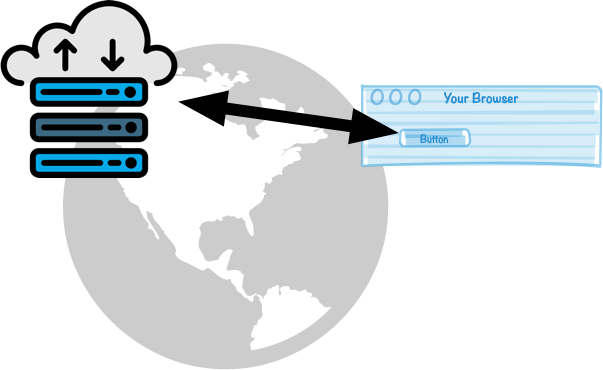

- Jupyter is like a **virtual server**, that runs on your computer.
- Your web browswer exchanges data with the Jupyter server

[figure not shown]

- This software setup means that:
  - Jupyter files can be flexibly run in any browser.
  - Jupyter files can be run on your local PC (if you have the Jupyter server installed) or over the internet (on an external server).
  - Users don't require Jupyter to be installed on their own computer. All they need is a browser and internet connection!